# RedWine Analysis By Gaganpreet Singh

#### Observation:

It shows high alcohol and low pH tend to produce better quality wines.

Lets analyze How other acids impact the PH:-

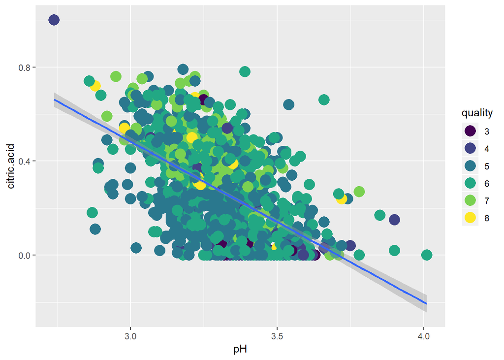

```r
ggplot(aes(x= pH, y = citric.acid), data = redwine)+ geom_point(aes(color= quality), size = 5) + scale_fill_brewer(type = 'div') +geom_smooth(method = 'lm')
```

It shows that high citric acid and low pH tend to produce high quality wines.

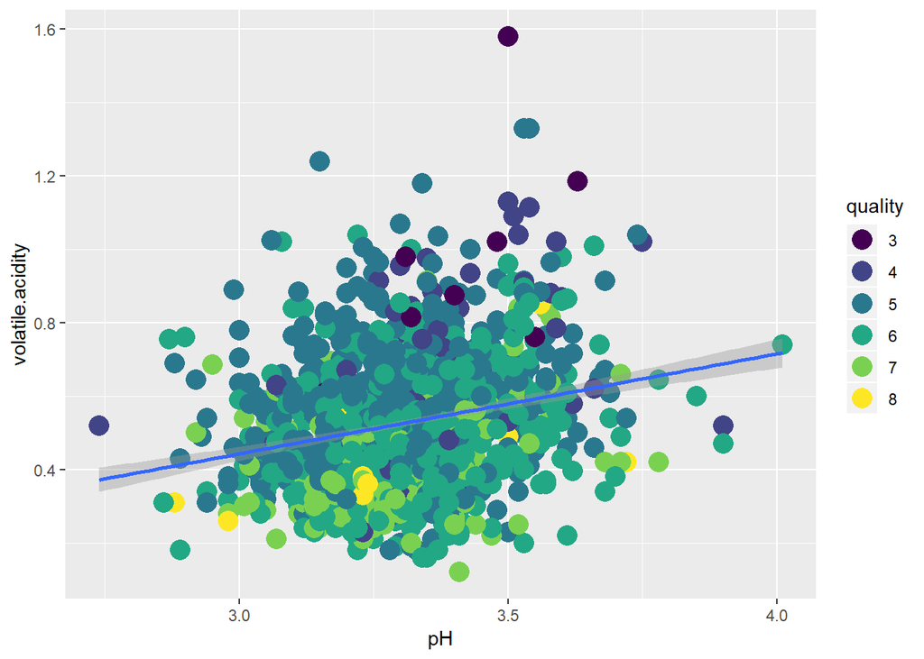

```r
ggplot(aes(x= pH, y = volatile.acidity), data = redwine)+ geom_point(aes(color= quality), size = 5) + scale_fill_brewer(type = 'div')+geom_smooth(method = 'lm')
```

#### Observation:

# Linear Modelling

Now after all the analysis, lets determine how much each variable is actually contributing in determining the quality of wines.

Before deciding for the final model, first i will create linear model for each independent variable seprately with quality of the wine. Based on each contribution, i will decide what variables should actually be determining the quality of the Red Wines

**Quality vs Alcohol**

```r
#linear model between quality and alcohol
summary(lm(formula = as.numeric(quality) ~ alcohol, data = redwine))
```

```
##
## Call:
## lm(formula = as.numeric(quality) ~ alcohol, data = redwine)
##
## Residuals:
##     Min      1Q  Median      3Q     Max
## -2.8442 -0.4112 -0.1690  0.5166  2.5888
##
## Coefficients:
##             Estimate Std. Error t value Pr(>|t|)
## (Intercept) -0.12503    0.17471  -0.716    0.474
## alcohol      0.36084    0.01668  21.639   <2e-16 ***
## ---
## Signif. codes:  0 '***' 0.001 '**' 0.01 '*' 0.05 '.' 0.1 ' ' 1
##
## Residual standard error: 0.7104 on 1597 degrees of freedom
## Multiple R-squared:  0.2267, Adjusted R-squared:  0.2263
## F-statistic: 468.3 on 1 and 1597 DF,  p-value: < 2.2e-16
```

#### Observation:

Based on R squared value, we can say Alcohol can explain 22% of variance in Quality of the Red wine.

**Quality vs Sulphates**

```r
summary(lm(formula = as.numeric(quality) ~ sulphates, data = redwine))
```

```
##
## Call:
## lm(formula = as.numeric(quality) ~ sulphates, data = redwine)
##
## Residuals:
##     Min      1Q  Median      3Q     Max
## -3.2432 -0.5424  0.1102  0.4456  2.3977
##
## Coefficients:
##             Estimate Std. Error t value Pr(>|t|)
## (Intercept)  2.84775    0.07842   36.31   <2e-16 ***
## sulphates    1.19771    0.11539   10.38   <2e-16 ***
## ---
## Signif. codes:  0 '***' 0.001 '**' 0.01 '*' 0.05 '.' 0.1 ' ' 1
##
## Residual standard error: 0.7819 on 1597 degrees of freedom
## Multiple R-squared:  0.0632, Adjusted R-squared:  0.06261
## F-statistic: 107.7 on 1 and 1597 DF,  p-value: < 2.2e-16
```

#### Observation:

Sulphates ten to contribute only 6% to the Quality of the Red wine. It is low value but significant as P-value is less than 0.05.

**Quality vs pH**

```r
#linear model between quality and pH

summary(lm(formula = as.numeric(quality) ~ pH, data = redwine))
```

```
##
## Call:
## lm(formula = as.numeric(quality) ~ pH, data = redwine)
##
## Residuals:
##     Min      1Q  Median      3Q     Max
## -2.6817 -0.6394  0.3032  0.3878  2.4874
##
## Coefficients:
##             Estimate Std. Error t value Pr(>|t|)
## (Intercept)   4.6359     0.4332  10.703   <2e-16 ***
## pH           -0.3020     0.1307  -2.311    0.021 *
## ---
## Signif. codes:  0 '***' 0.001 '**' 0.01 '*' 0.05 '.' 0.1 ' ' 1
##
## Residual standard error: 0.8065 on 1597 degrees of freedom
## Multiple R-squared:  0.003333,   Adjusted R-squared:  0.002709
## F-statistic:  5.34 on 1 and 1597 DF,  p-value: 0.02096
```

#### Observation:

```r
summary(lm(formula = as.numeric(quality) ~ density, data = redwine))
```

```
##
## Call:
## lm(formula = as.numeric(quality) ~ density, data = redwine)
##
## Residuals:
##     Min      1Q  Median      3Q     Max
## -2.7885 -0.6216  0.1554  0.4271  2.5177
##
## Coefficients:
##             Estimate Std. Error t value Pr(>|t|)
## (Intercept)    78.24      10.51   7.446 1.57e-13 ***
## density       -74.85      10.54  -7.100 1.87e-12 ***
## ---
## Signif. codes:  0 '***' 0.001 '**' 0.01 '*' 0.05 '.' 0.1 ' ' 1
##
## Residual standard error: 0.7954 on 1597 degrees of freedom
## Multiple R-squared:  0.0306, Adjusted R-squared:  0.02999
## F-statistic: 50.41 on 1 and 1597 DF,  p-value: 1.875e-12
```

**Quality vs citric acid**

```r
#linear model between quality and citric acid

summary(lm(formula = as.numeric(quality) ~ citric.acid, data = redwine))
```

```
##
## Call:
## lm(formula = as.numeric(quality) ~ citric.acid, data = redwine)
##
## Residuals:
##     Min      1Q  Median      3Q     Max
## -3.0011 -0.5976  0.1021  0.5057  2.5901
##
## Coefficients:
##             Estimate Std. Error t value Pr(>|t|)
## (Intercept)  3.38172    0.03372 100.294   <2e-16 ***
## citric.acid  0.93845    0.10104   9.288   <2e-16 ***
## ---
## Signif. codes:  0 '***' 0.001 '**' 0.01 '*' 0.05 '.' 0.1 ' ' 1
##
## Residual standard error: 0.7869 on 1597 degrees of freedom
## Multiple R-squared:  0.05124,    Adjusted R-squared:  0.05065
## F-statistic: 86.26 on 1 and 1597 DF,  p-value: < 2.2e-16
```

#### Observation:

Citric acid tend to contribute only 5% to the Quality of the Red wine. It is low value but significant i.e reliable.

**Quality vs Volatile acidity**

```r
summary(lm(formula = as.numeric(quality) ~ volatile.acidity, data = redwine))
```

```
##
## Call:
## lm(formula = as.numeric(quality) ~ volatile.acidity, data = redwine)
##
## Residuals:
##      Min       1Q   Median       3Q      Max
## -2.79071 -0.54411 -0.00687  0.47350  2.93148
##
## Coefficients:
##                  Estimate Std. Error t value Pr(>|t|)
## (Intercept)       4.56575    0.05791   78.85   <2e-16 ***
## volatile.acidity -1.76144    0.10389  -16.95   <2e-16 ***
## ---
## Signif. codes:  0 '***' 0.001 '**' 0.01 '*' 0.05 '.' 0.1 ' ' 1
##
## Residual standard error: 0.7437 on 1597 degrees of freedom
## Multiple R-squared:  0.1525, Adjusted R-squared:  0.152
## F-statistic: 287.4 on 1 and 1597 DF,  p-value: < 2.2e-16
```

#### Observation:

This is not what i expected, volatile acidity seems to be contributing **15%** to the quality of the red wine.

**Quality vs Fixed acidity**

```r
#linear model between quality and Fixed acidity

summary(lm(formula = as.numeric(quality) ~ fixed.acidity, data = redwine))
```

```
##
## Call:
## lm(formula = as.numeric(quality) ~ fixed.acidity, data = redwine)
##
## Residuals:
##     Min      1Q  Median      3Q     Max
## -2.8248 -0.6061  0.1925  0.4341  2.5550
##
## Coefficients:
##               Estimate Std. Error t value Pr(>|t|)
## (Intercept)    3.15732    0.09789  32.253  < 2e-16 ***
## fixed.acidity  0.05754    0.01152   4.996  6.5e-07 ***
## ---
## Signif. codes:  0 '***' 0.001 '**' 0.01 '*' 0.05 '.' 0.1 ' ' 1
##
## Residual standard error: 0.8016 on 1597 degrees of freedom
## Multiple R-squared:  0.01539,    Adjusted R-squared:  0.01477
## F-statistic: 24.96 on 1 and 1597 DF,  p-value: 6.496e-07
```

#### Observation:

FIxed acidity doesn’t seems to be contributing to the quality of the red wine with R-square value of only **1.4**.

# Final Linear Model

Considering the individual R square value and correlation with quality variable, I have decided to create final linear model with below 4 independent variables :-

Dependent Variable: **Quality**

Independent variables: **Alcohol, Sulphates, Citric acid, Volatile Acidity**

Here is the our Model results:-

```r
#ploting linear model between Quality & Alcohol, sulphates, citric acid, volatile acidity
m1 <- lm(formula = as.numeric(quality) ~ alcohol, data = redwine)
m2 <- lm(as.numeric(quality)~alcohol + sulphates, data = redwine)
m3 <- lm(as.numeric(quality)~alcohol + sulphates + citric.acid, data = redwine)
m4 <- lm(as.numeric(quality)~alcohol + sulphates + citric.acid + volatile.acidity, data = redwine)

mtable(m1, m2, m3 , m4)
```

```
##
## Calls:
## m1: lm(formula = as.numeric(quality) ~ alcohol, data = redwine)
## m2: lm(formula = as.numeric(quality) ~ alcohol + sulphates, data = redwine)
## m3: lm(formula = as.numeric(quality) ~ alcohol + sulphates + citric.acid,
##     data = redwine)
## m4: lm(formula = as.numeric(quality) ~ alcohol + sulphates + citric.acid +
##     volatile.acidity, data = redwine)
##
## ============================================================================
##                          m1            m2            m3            m4
## ----------------------------------------------------------------------------
##   (Intercept)          -0.125        -0.625***     -0.566**       0.646**
##                        (0.175)       (0.177)       (0.176)       (0.201)
##   alcohol               0.361***      0.346***      0.338***      0.309***
##                        (0.017)       (0.016)       (0.016)       (0.016)
##   sulphates                           0.994***      0.814***      0.696***
##                                      (0.102)       (0.107)       (0.103)
##   citric.acid                                       0.513***     -0.079
##                                                    (0.093)       (0.104)
##   volatile.acidity                                               -1.265***
##                                                                  (0.113)
## ----------------------------------------------------------------------------
##   R-squared             0.227         0.270         0.284         0.336
##   adj. R-squared        0.226         0.269         0.282         0.334
##   sigma                 0.710         0.690         0.684         0.659
##   F                   468.267       294.988       210.501       201.777
##   p                     0.000         0.000         0.000         0.000
##   Log-likelihood    -1721.057     -1675.142     -1659.955     -1599.093
##   Deviance            805.870       760.894       746.576       691.852
##   AIC                3448.114      3358.284      3329.910      3210.186
##   BIC                3464.245      3379.793      3356.795      3242.448
##   N                  1599          1599          1599          1599
## ============================================================================
```

# Multivariate Plot Analysis

#### Talk about some of the relationships you observed in this part of the investigation. Were there features that strengthened each other in terms of looking at your feature(s) of interest?

1. High Alcohol and high Sulphates concentration seems to produce good quality wines.
2. Similar beahviour is shown by Citric acid

### Linear Model Summary

I created couple of linear model for observing the individual contribution of the variable in explaining the variance in quality of the red wines. **Alcohol and Volatile Acidity** comes out to be most important factor by contributing **22% and 15%** respectively in determining the quality of the wines.

Consolidating all the key variables, my final model includes **Alcohol, Volatile Acididty, Citric acid, Sulphates** which all together can explain approximately **33 %** of the variance in quality of Red wines.

This might be good result as it can be due to the fact that our dataset comprised mainly of **‘Average’** quality wines and as there were very few data about the ‘Good’ and the ‘Bad’ quality wines in our dataset. More observations about **‘bad’** and **‘good’** quality wines would have helped me better in predicting the quality of red wine effectively.

# Final Plots & Summary

## Plot 1

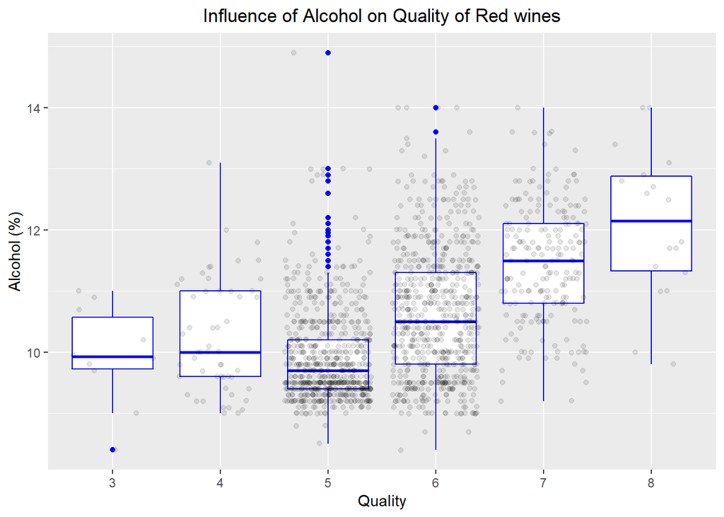

```r
ggplot(aes(x = quality, y = alcohol), data = redwine) + geom_boxplot(color = 'blue')+ ggtitle("Influence of Alcohol on Quality of Red wines") + geom_jitter(alpha=1/10)+ theme(plot.title = element_text(hjust = 0.5)) + xlab("Quality") + ylab("Alcohol (%)")
```

## Plot 2

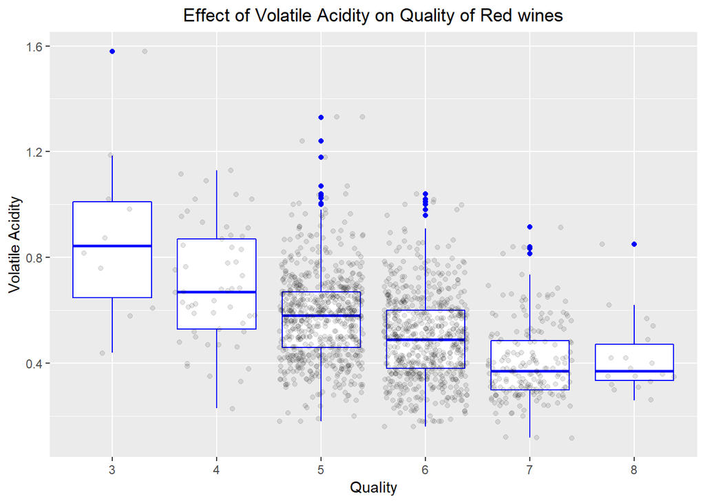

```r
ggplot(aes(x = quality, y = volatile.acidity), data = redwine) + geom_boxplot(color = 'blue')+ ggtitle("Effect of Volatile Acidity on Quality of Red wines") + geom_jitter(alpha=1/10)+ theme(plot.title = element_text(hjust = 0.5)) + xlab("Quality") + ylab("Volatile Acidity")
```

### Description -

1. This plot shows us that VOlatile acidity concentration has also played a significant role in determining the quality of Wines.
2. Lower the Volatile acidity, the better the wine quality. But this isn’t the case with other acid parameters included in data set.
3. Also, from our linear model test, we saw that Volatile acidity contributes around **15%** to quality of red wines.

## Plot 3

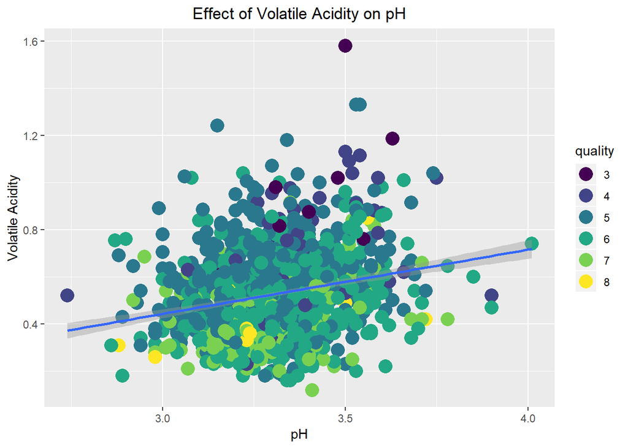

```r
ggplot(aes(x= pH, y = volatile.acidity), data = redwine)+ geom_point(aes(color= quality), size = 5) + scale_fill_brewer(type = 'div')+geom_smooth(method = 'lm') + ggtitle("Effect of Volatile Acidity on pH") + theme(plot.title = element_text(hjust = 0.5)) + xlab("pH") + ylab("Volatile Acidity")
```

### Description -

1. This comes out to be more unexpected result of this complete analysis.
2. Its strange to see why volatile acidity have positive correlation with pH. Generally, pH decrease with increase with in acidity
3. Reason for this probably be the limited number of observations for Quality 3, 4, 7 and 8 as most of the observations are for Averge quality wines i.e 5 and 6.
4. Another probable reason of this might be Simson paradox.

# Reflection

Redwine dataset consists of 1599 observation for 13 variable consisting of various physical and chemical properties of Red wine.

First I plotted different variables against the quality to see Univariate relationships between them and then I plotted each variable against Quality to see which are significant in determining quality of the wine. I saw that the factors which affected the quality of the wine the most were Alcohol percentage, Sulphate and Citric acid and Volatile Acidity.

I tried to figure out the effect of each individual acid on the overall pH of the wine. Here I found out a very strange phenomenon where I saw that for volatile acids, the pH was increasing with acidity which was against general property of acids.

In the final part of my analysis, I plotted multivariate plots to see if there were some interesting combinations of variables which together affected the overall quality of the wine. These plots also help me to finalize the final variables which i need to put in linear model to predict the quality of wine.

While performing the analysis, my main struggle was to get a higher confidence level for predicting the the ‘Good’ and the ‘Bad’ quality wines as the data was very centralized towards the ‘Average’ quality, dataset set did not have enough data on the extreme edges i.e for wiuality 3,4 ,7, and 8 to accurately build a model which can predict the quality of a wine given the other variables with lesser margin of error. So maybe in future, if can get a dataset about Red Wines with more complete information i.e with more number of observations of every quality type, then I can build my models more effectively.